# Taller De Regresion Lineal Multiple

## Secto Punto

El siguiente modelo puede ser utilizado para estudiar si los gastos de una campaña afectan los resultados de la elección:

Vote A = porcentaje de votos del candidato A expendA= gastos de campaña candidato A expendB= gastos de campaña candidato B prtystrA= porcentaje de votos obtenido por el pardito de A en la elección más reciente

#Estimacion del Modelo

```r
rm(list=ls()) # rm remueve objetos, ls = lista
setwd('C://Users/f-pis/Desktop/Semestres/Archivos R') #Establece el workDirectory
#install.packages("readxl") # instala el paquete para leer Excel
library(readxl) #..library() Carga el paquete
Datos_6P<-read_excel("Datos_E6_Votacion.xls") #read_excel lee el excel
Datos_6P=data.frame(Datos_6P)
kable(head(Datos_6P))
```

| voteA | expendA | expendB | prtystrA |
| --- | --- | --- | --- |
| 68 | 328.30 | 8.74 | 41 |
| 62 | 626.38 | 402.48 | 60 |
| 73 | 99.61 | 3.07 | 55 |
| 69 | 319.69 | 26.28 | 64 |
| 75 | 159.22 | 60.05 | 66 |
| 69 | 570.16 | 21.39 | 46 |

```r
voteA=Datos_6P[,1]
logExpendA=log(Datos_6P[,2])
logExpendB=log(Datos_6P[,3])
prtystrA=Datos_6P[,4]

Reg_6=lm(voteA~logExpendA+logExpendB+prtystrA)
summary(Reg_6)
```

```
##
## Call:
## lm(formula = voteA ~ logExpendA + logExpendB + prtystrA)
##
## Residuals:
##      Min       1Q   Median       3Q      Max
## -20.3990  -5.4184  -0.8737   4.9563  26.0575
##
## Coefficients:
##             Estimate Std. Error t value Pr(>|t|)
## (Intercept) 45.08788    3.92680  11.482   <2e-16 ***
## logExpendA   6.08136    0.38211  15.915   <2e-16 ***
## logExpendB  -6.61563    0.37889 -17.461   <2e-16 ***
## prtystrA     0.15201    0.06203   2.451   0.0153 *
## ---
## Signif. codes:  0 '***' 0.001 '**' 0.01 '*' 0.05 '.' 0.1 ' ' 1
##
## Residual standard error: 7.713 on 169 degrees of freedom
## Multiple R-squared:  0.7925, Adjusted R-squared:  0.7888
## F-statistic: 215.2 on 3 and 169 DF,  p-value: < 2.2e-16
```

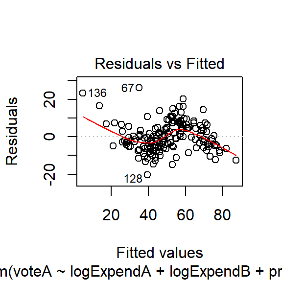

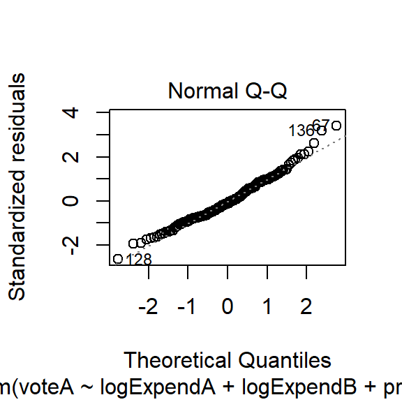

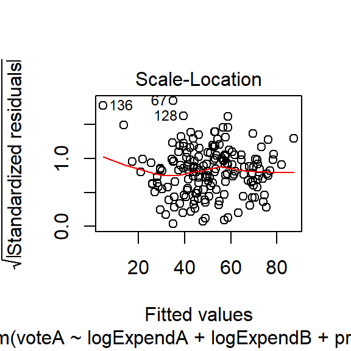

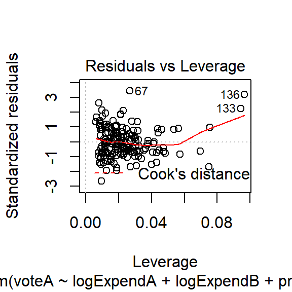

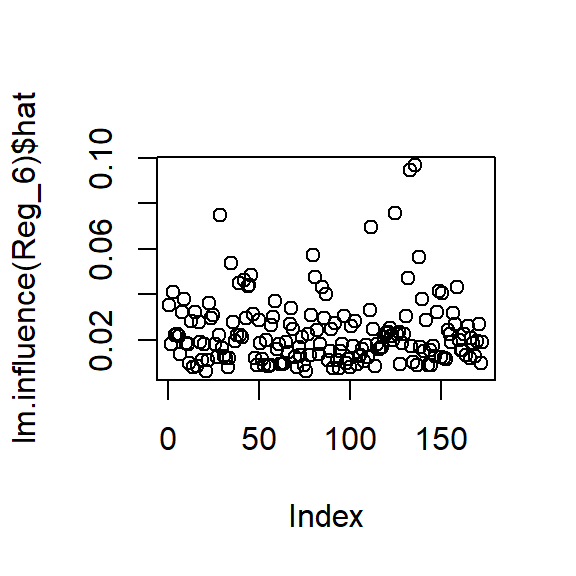

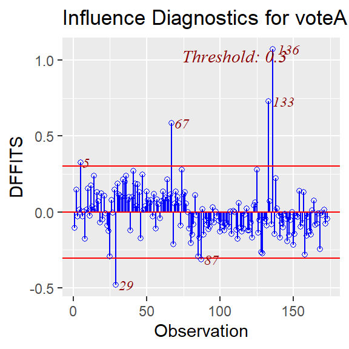

```r
RSS_NR6=deviance(Reg_6)
plot(Reg_6)
plot(lm.influence(Reg_6)$hat)

if (!require("olsrr"))
{
  install.packages('olsrr');
  library(rolsrr);
}
library(olsrr)
require(olsrr)
ols_plot_dffits(Reg_6)
```

## Prueba de Hipotesis

Pruebe la hipótesis según la cual un aumento de 1% en los gastos de A se compensa por un aumento de 1% en los gastos de B. Utilice las pruebas lr,Wald y LM

Ho: b1-b2=0 Ha: b1-b2!=0

### Estimacion del modelo 6 restringido

```r
"ESTIMACIÓN DEL MODELO 6 RESTINGIDO CON LA FUNCIÓN lm()"
```

```
## [1] "ESTIMACIÓN DEL MODELO 6 RESTINGIDO CON LA FUNCIÓN lm()"
```

```r
if (!require("restriktor"))
{
  install.packages('restriktor');
  library(restriktor);
}
library(restriktor)

Restricciones <- '
logExpendA-logExpendB ==0;'
Reg_6R = restriktor(Reg_6, constraints = Restricciones)
summary(Reg_6R)
```

```
##
## Call:
## conLM.lm(object = object, constraints = constraints)
##
## Restriktor: restricted linear model:
##
## Residuals:
##      Min       1Q   Median       3Q      Max
## -33.5332 -14.1190   0.7192  14.0651  34.6726
##
## Coefficients:
##             Estimate Std. Error t value  Pr(>|t|)
## (Intercept) 24.44182    7.85032  3.1135  0.002172 **
## logExpendA  -0.31997    0.54688 -0.5851  0.559278
## logExpendB  -0.31997    0.54688 -0.5851  0.559278
## prtystrA     0.58788    0.12138  4.8434 2.868e-06 ***
## ---
## Signif. codes:  0 '***' 0.001 '**' 0.01 '*' 0.05 '.' 0.1 ' ' 1
##
## Residual standard error: 15.826 on 169 degrees of freedom
## Standard errors: standard
## Multiple R-squared reduced from 0.793 to 0.121
##
## Generalized order-restricted information criterion:
##  Loglik Penalty   goric
## -721.73    4.00 1451.45
```

```r
"Estos son los estimadores OLS del modelo 5 restringido"
```

```
## [1] "Estos son los estimadores OLS del modelo 5 restringido"
```

```r
(b6R=coef(Reg_6R))
```

```
## (Intercept)  logExpendA  logExpendB    prtystrA
##  24.4418217  -0.3199659  -0.3199659   0.5878761
```

```r
sR6_mr=summary(Reg_6R)
"LA VARIANZA ESTIMADA DEL MODELO RESTRINGIDO ES"
```

```
## [1] "LA VARIANZA ESTIMADA DEL MODELO RESTRINGIDO ES"
```

```r
S2_mr6=sR6_mr$s2
S2_mr6
```

```
## [1] 250.4518
```

```r
" EL ERROR ESTÁNDAR DEL MODELO RESTRINGIDO ES"
```

```
## [1] " EL ERROR ESTÁNDAR DEL MODELO RESTRINGIDO ES"
```

```r
s_mr6=(sR6_mr$s2)^0.5
s_mr6
```

```
## [1] 15.82567
```

```r
"LA SUMA DE CUADRADOS DE LOS ERROES DEL MODELO RESTRINGIDO ES: RSS_R=S2_mr*(n-(k-1))"
```

```
## [1] "LA SUMA DE CUADRADOS DE LOS ERROES DEL MODELO RESTRINGIDO ES: RSS_R=S2_mr*(n-(k-1))"
```

```r
RSS_R6=170*S2_mr6
RSS_R6
```

```
## [1] 42576.8
```

## Prueba LR Razon de Verosimilitud

```r
#PRUEBA LR: RAZÓN DE VEROSIMILITUD
"PRUEBA LR: RAZÓN DE VEROSIMILITUD"
```

```
## [1] "PRUEBA LR: RAZÓN DE VEROSIMILITUD"
```

```r
"LA SUMA DE LOS CUADRADOS DE LOS ERRORES DEL MODELO NO RESTRINGIDO ES"
```

```
## [1] "LA SUMA DE LOS CUADRADOS DE LOS ERRORES DEL MODELO NO RESTRINGIDO ES"
```

```r
"RSS_NR6"
```

```
## [1] "RSS_NR6"
```

```r
RSS_NR6
```

```
## [1] 10054.83
```

```r
npi=pi
n=173
k=3
"El numero e"
```

```
## [1] "El numero e"
```

```r
e=exp(1)

(LMR6=((2*npi*e/n)^(-n/2))*((RSS_R6)^(-n/2)))
```

```
## [1] 0
```

```r
"El logaritmo de la verosimilitud restringida es"
```

```
## [1] "El logaritmo de la verosimilitud restringida es"
```

```r
(lmr6=log(LMR6))
```

```
## [1] -Inf
```

```r
"LA SUMA DE LOS CUADRADOS DE LOS ERRORES DEL MODELO RESTRINGIDO ES"
```

```
## [1] "LA SUMA DE LOS CUADRADOS DE LOS ERRORES DEL MODELO RESTRINGIDO ES"
```

```r
"RSS_R6"
```

```
## [1] "RSS_R6"
```

```r
RSS_R6
```

```
## [1] 42576.8
```

```r
"LA VEROSIMILITUD DEL MODELO NO RESTRINGIDO ES:"
```

```
## [1] "LA VEROSIMILITUD DEL MODELO NO RESTRINGIDO ES:"
```

```r
(LMNR6=((2*npi*e/n)^(-n/2))*((RSS_NR6)^(-n/2)))
```

```
## [1] 0
```

```r
"El logaritmo de la verosimilitud no restringido es"
```

```
## [1] "El logaritmo de la verosimilitud no restringido es"
```

```r
(lmnr6=log(LMNR6))
```

```
## [1] -Inf
```

```r
"LA ESTADÍSTICA CALCULADA DE LA ECUACIÓN 17 ES"
```

```
## [1] "LA ESTADÍSTICA CALCULADA DE LA ECUACIÓN 17 ES"
```

```r
"LR_C_17"
```

```
## [1] "LR_C_17"
```

```r
(LRC_17=-2*(lmnr6-lmr6)) ##LR=2*ln(lambda)
```

```
## [1] NaN
```

```r
"Valores grandes de LR nos indican que lambda tiende a ceroy por esta razón debemos rechazar Ho y decimos que logExpendA-logExpendB !==0 "
```

```
## [1] "Valores grandes de LR nos indican que lambda tiende a ceroy por esta razón debemos rechazar Ho y decimos que logExpendA-logExpendB !==0 "
```

```r
"LA ESTADÍSTICA CALCULADA DE LA ECUACIÓN 18 ES"
```

```
## [1] "LA ESTADÍSTICA CALCULADA DE LA ECUACIÓN 18 ES"
```

```r
"LR_C_18"
```

```
## [1] "LR_C_18"
```

```r
(LRC_18=173*log(RSS_R6/RSS_NR6))  #LR=n*(ln(RSS_R)-ln(RSS_NR))
```

```
## [1] 249.6834
```

```r
"EL VALOR P PARA LA PRUEBA ES"
```

```
## [1] "EL VALOR P PARA LA PRUEBA ES"
```

```r
(pv_valor=pchisq(LRC_18,df = 1, lower.tail = F))
```

```
## [1] 3.044172e-56
```

Valores grandes de LR nos indican que lambda tiende a ceroy por esta razón debemos rechazar Ho y decimos que logExpendA-logExpendB !==0

##Prueba de wald

```r
"ESTADÍSTICA F DE WALD DE LA ECUACIÓN F (20)"
```

```
## [1] "ESTADÍSTICA F DE WALD DE LA ECUACIÓN F (20)"
```

```r
"El valor calculado de esta estadística es:"
```

```
## [1] "El valor calculado de esta estadística es:"
```

```r
"FC_20"
```

```
## [1] "FC_20"
```

```r
(FC_20W=n*(RSS_R6-RSS_NR6)/RSS_NR6)
```

```
## [1] 559.562
```

```r
"EL VALOR P PARA LA PRUEBA ES"
```

```
## [1] "EL VALOR P PARA LA PRUEBA ES"
```

```r
(pv_wald=pchisq(FC_20W,df=1,lower.tail = F))
```

```
## [1] 1.046861e-123
```

## Prueba LM

Multiplicadores de Lagrange

```r
#options(digits=4)
"REGRESIÓN AUXILIAR PARA LA PRUEBA LM"
```

```
## [1] "REGRESIÓN AUXILIAR PARA LA PRUEBA LM"
```

```r
"Errores de estimación etr del modelo restingido vs X2t, X2t"
```

```
## [1] "Errores de estimación etr del modelo restingido vs X2t, X2t"
```

```r
etr6=resid(Reg_6R)
Reg_6aux=lm(etr6~logExpendA+logExpendB+prtystrA)
(sReg_6aux_lm=summary(Reg_6aux))
```

```
##
## Call:
## lm(formula = etr6 ~ logExpendA + logExpendB + prtystrA)
##
## Residuals:
##      Min       1Q   Median       3Q      Max
## -20.3990  -5.4184  -0.8737   4.9563  26.0575
##
## Coefficients:
##             Estimate Std. Error t value Pr(>|t|)
## (Intercept) 20.64606    3.92680   5.258 4.36e-07 ***
## logExpendA   6.40132    0.38211  16.752  < 2e-16 ***
## logExpendB  -6.29566    0.37889 -16.616  < 2e-16 ***
## prtystrA    -0.43586    0.06203  -7.027 4.95e-11 ***
## ---
## Signif. codes:  0 '***' 0.001 '**' 0.01 '*' 0.05 '.' 0.1 ' ' 1
##
## Residual standard error: 7.713 on 169 degrees of freedom
## Multiple R-squared:  0.7638, Adjusted R-squared:  0.7597
## F-statistic: 182.2 on 3 and 169 DF,  p-value: < 2.2e-16
```

```r
"El R2_aux para la prueba LM es el R2 de la regresión auxiliar"
```

```
## [1] "El R2_aux para la prueba LM es el R2 de la regresión auxiliar"
```

```r
"El R2_aux es"
```

```
## [1] "El R2_aux es"
```

```r
R2_aux=0.7638

R2_aux
```

```
## [1] 0.7638
```

```r
(LM6_22=n*R2_aux)
```

```
## [1] 132.1374
```

```r
(LM6_23=n*(RSS_R6- RSS_NR6)/(RSS_R6))
```

```
## [1] 132.1448
```

```r
(pv_LM6=pchisq(LM6_22,df=1,lower.tail = F))
```

```
## [1] 1.396139e-30
```

```r
(pv_LM6_23=pchisq(LM6_23,df=1,lower.tail = F))
```

```
## [1] 1.390974e-30
```

```r
"Ya que P_val <<alpha concluimos que se rechaza Ho y por lo tanto logExpendA-logExpendB!==0 "
```

```
## [1] "Ya que P_val <<alpha concluimos que se rechaza Ho y por lo tanto logExpendA-logExpendB!==0 "
```

Ya que P_val <<alpha concluimos que se rechaza Ho y por lo tanto logExpendA-logExpendB!==0